# Logistic regression of C. difficile ~ C. hiranonis

Michael McLaren

2019-07-24

## Setup

```r
library(here)
library(phyloseq)
library(tidyverse)
library(ggbeeswarm)
library(ggthemes)
library(ggstance)
library(cowplot)
library(brms)
library(tidybayes)
# Custom functions and plot setup
source(here("analysis", "functions-and-ggplot-setup.R"))
```

```r
ps <- readRDS(here("results", "ps.Rds")) %>%
    subset_samples(Host_species %in% c("Canine", "Feline", "Equine",
            "Ovine")) %>%
    filter_taxa(function (x) sum(x) > 0, prune = TRUE)
# Make variable CD to be our indicator of Cdiff presence for this analysis
sample_data(ps)$CD <- sample_data(ps)$CD_either
# Shorten the sample names
sample_names(ps) <- sample_names(ps) %>%
    str_match("(.+)_") %>%
    .[,2]
sam <- sample_data(ps) %>% as_tibble
```

Get a data frame formatted for the regressions

```r
tb <- ps %>%
    subset_samples(Host_species == "Canine") %>%
    prune_taxa(c("ASV4", "ASV62"), .) %>%
    as_tibble(tax = FALSE) %>%
    spread(Taxon, Abundance) %>%
    mutate(
        CH = factor((ASV4 > 0) + (ASV62 > 0)),
        ASV4_present = ASV4 > 0,
        ASV62_present = ASV62 > 0
    )
```

The variable `CH` indicates whether 0, 1, or 2 of the two ASVs are present in the sample; thus `CH==1` and `CH==2` correspond to the two putative C. hiranonis strains. Since ASV4 is always present if any C. hiranonis ASV is, we can use ASV4 presence as an indicator of C. hiranonis presence.

Set the seed,

```r
set.seed(42)
```

## Failure of standard logistic regression due to perfect separation

Since all canines with ASV62 are CD-, standard logistic regression with the `glm` function can’t be used to estimate the effect of ASV62 or CH2,

```r
m1 <- glm(data = tb, family = binomial, CD ~ CH)
m1
```

```
##
## Call:  glm(formula = CD ~ CH, family = binomial, data = tb)
##
## Coefficients:
## (Intercept)          CH1          CH2
##     0.04082     -1.29358    -18.60689
##
## Degrees of Freedom: 103 Total (i.e. Null);  101 Residual
## Null Deviance:       130
## Residual Deviance: 106   AIC: 112
```

```r
confint(m1)
```

[output not shown]

```
##                  2.5 %     97.5 %
## (Intercept) -0.5218929  0.6056909
## CH1         -2.3059568 -0.3595008
## CH2                 NA 69.1510331
```

## Bayesian logistic regression

We can solve this problem by using Bayesian logistic regression with weakly-informative priors to bound the effect sizes.

### Picking priors

We’ll use a t distribution with 7 degrees of freedom with the spread set so that the 0.01 and 0.99 quantiles on the baseline Cdiff prevalence are roughly 0.01 and 0.99 (e.g., less than 0.01 probability of a prevalance < 0.01),

```r
df_t <- 7
sigma_t <- 1.53
inv_logit_scaled(qt(c(0.01, 0.1, 0.9, 0.99), df_t) * sigma_t)
```

```
## [1] 0.01008205 0.10295319 0.89704681 0.98991795
```

and that the odds ratios are bounded so that the 0.01 and 0.99 quantiles correspond to odds ratios of 1/200 and 200,

```r
df_t <- 7
sigma_t <- 1.77
exp(qt(c(0.01, 0.1, 0.9, 0.99), 7) * sigma_t)
```

```
## [1] 4.959877e-03 8.172336e-02 1.223640e+01 2.016179e+02
```

```r
base_prior <- c(
    prior(student_t(7, 0, 1.53), class = Intercept),
    prior(student_t(7, 0, 1.77), class = b)
)
```

### C. hiranonis-only model

```r
b1 <- brm(data = tb, family = bernoulli, CD ~ CH,
    prior = base_prior)
b1
```

```
##  Family: bernoulli
##   Links: mu = logit
## Formula: CD ~ CH
##    Data: tb (Number of observations: 104)
## Samples: 4 chains, each with iter = 2000; warmup = 1000; thin = 1;
##          total post-warmup samples = 4000
##
## Population-Level Effects:
##           Estimate Est.Error l-95% CI u-95% CI Eff.Sample Rhat
## Intercept    -0.03      0.28    -0.57     0.52       3710 1.00
## CH1          -1.18      0.47    -2.10    -0.29       2658 1.00
## CH2          -3.60      1.33    -6.87    -1.53       1594 1.00
##
## Samples were drawn using sampling(NUTS). For each parameter, Eff.Sample
## is a crude measure of effective sample size, and Rhat is the potential
## scale reduction factor on split chains (at convergence, Rhat = 1).
```

Here, CH1 and CH2 denote the effects of the putative different strains of C. hiranonis.

Note, we expect the estimate for CH2 is sensitive to the width of the prior due to the lack of any CD+ canines with ASV62.

Baseline prevalence:

```r
b1 %>%
    fixef(pars = "Intercept", probs = c(0.05, 0.1, 0.9, 0.95)) %>%
    inv_logit_scaled
```

```
##            Estimate Est.Error        Q5       Q10       Q90       Q95
## Intercept 0.4924929 0.5693381 0.3820703 0.4045236 0.5821082 0.6047847
```

Coefficients in log-odds space:

```r
b1 %>%
    fixef(probs = c(0.05, 0.1, 0.9, 0.95))
```

```
##              Estimate Est.Error         Q5        Q10        Q90
## Intercept -0.03003085 0.2791511 -0.4807699 -0.3866515  0.3314339
## CH1       -1.17578525 0.4744410 -1.9588268 -1.7926148 -0.5648845
## CH2       -3.60211497 1.3343846 -6.0873422 -5.3224660 -2.1284314
##                  Q95
## Intercept  0.4254419
## CH1       -0.4109184
## CH2       -1.8028743
```

Odds-ratios:

```r
b1 %>%
    fixef(probs = c(0.05, 0.1, 0.9, 0.95)) %>%
    exp
```

```
##             Estimate Est.Error          Q5         Q10       Q90       Q95
## Intercept 0.97041559  1.322007 0.618307169 0.679327813 1.3929641 1.5302666
## CH1       0.30857658  1.607116 0.141023779 0.166524170 0.5684258 0.6630410
## CH2       0.02726599  3.797658 0.002271438 0.004880703 0.1190239 0.1648245
```

### Antibiotics, GI status, and Sex

Note, there are four samples that are missing information about these variables, and so we need to first remove these samples.

```r
tb %>%
    filter_at(vars(Ab_status, GI_status, Sex), any_vars( . == "Not known")) %>%
    select(Sample, Ab_status, GI_status, Sex)
```

```
## # A tibble: 4 x 4
##   Sample Ab_status   GI_status    Sex
##   <chr>  <fct>       <fct>        <fct>
## 1 CS106  Not known   Not known    Not known
## 2 CS14   Non-treated Not known    F
## 3 CS158  Not known   Not known    M
## 4 CS186  Non-treated GI condition Not known
```

```r
tb2 <- tb %>%
    filter_at(vars(Ab_status, GI_status, Sex), all_vars(. != "Not known")) %>%
    mutate_at(vars(Ab_status, GI_status, Sex), fct_drop)
tb2 %>%
    group_by(Ab_status, GI_status, Sex) %>%
    count
```

```
## # A tibble: 8 x 4
## # Groups:   Ab_status, GI_status, Sex [8]
##   Ab_status   GI_status    Sex       n
##   <fct>       <fct>        <fct> <int>
## 1 Non-treated Healthy      F        12
## 2 Non-treated Healthy      M        13
## 3 Non-treated GI condition F         5
## 4 Non-treated GI condition M        11
## 5 Treated     Healthy      F        12
## 6 Treated     Healthy      M        18
## 7 Treated     GI condition F        11
## 8 Treated     GI condition M        18
```

Now let’s add Antibiotics, GI status, and Sex to the model,

```r
b2 <- brm(data = tb2, family = bernoulli,
    CD ~ Ab_status + GI_status + Sex + CH,
    prior = base_prior
)
b2
```

```
##  Family: bernoulli
##   Links: mu = logit
## Formula: CD ~ Ab_status + GI_status + Sex + CH
##    Data: tb2 (Number of observations: 100)
## Samples: 4 chains, each with iter = 2000; warmup = 1000; thin = 1;
##          total post-warmup samples = 4000
##
## Population-Level Effects:
##                      Estimate Est.Error l-95% CI u-95% CI Eff.Sample Rhat
## Intercept               -1.28      0.63    -2.55    -0.10       4999 1.00
## Ab_statusTreated         0.91      0.53    -0.14     1.98       5367 1.00
## GI_statusGIcondition    -0.21      0.47    -1.16     0.72       5326 1.00
## SexM                     1.07      0.51     0.10     2.11       4395 1.00
## CH1                     -1.11      0.51    -2.15    -0.13       5317 1.00
## CH2                     -3.46      1.37    -6.76    -1.32       2452 1.00
##
## Samples were drawn using sampling(NUTS). For each parameter, Eff.Sample
## is a crude measure of effective sample size, and Rhat is the potential
## scale reduction factor on split chains (at convergence, Rhat = 1).
```

Plot:

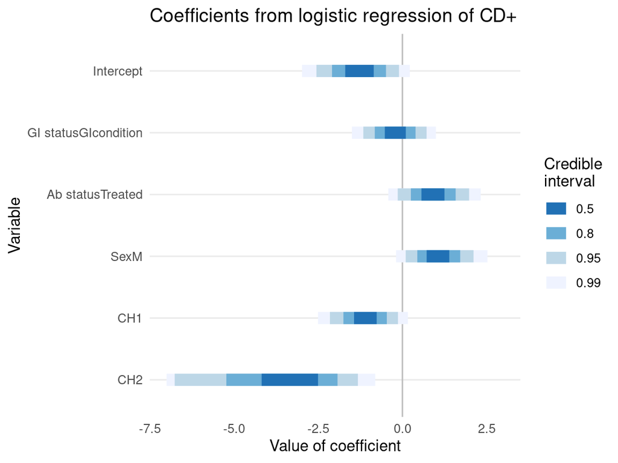

```r
lvls <- paste0("b_", c("Intercept", "GI_statusGIcondition", "Ab_statusTreated",
        "SexM", "CH1", "CH2"))
labeller <- function(lvl) {
    lvl %>%
        str_replace("b_", "") %>%
        str_replace("_", " ")
}
b2 %>%
    gather_draws(`b_.+`, regex = TRUE) %>%
    ggplot(aes(y = factor(.variable, rev(lvls)), x = .value)) +
    geom_vline(xintercept = 0, color = "grey") +
    stat_intervalh(.width = c(.50, .80, .95, .99)) +
    scale_x_continuous(limits = c(-7, 3), oob = scales::squish) +
    scale_y_discrete(labels = labeller) +
    scale_color_brewer() +
    labs(y = "Variable", x = "Value of coefficient",
        title = "Coefficients from logistic regression of CD+",
        color = "Credible\ninterval") +
    guides(colour = guide_legend(reverse = TRUE)) +
    theme_minimal() +
    theme(panel.grid.major.x = element_blank(),
        panel.grid.minor.x = element_blank())
```

```r
ggsave(here("figures", "logreg-cd.pdf"),
    width = 5, height = 3, units = "in")
```

Note, the lower end of the credible interval for the `CH2` coefficient is clipped at `-7`.

### Age

Now we’ll add age to the model. As before, we’ll drop the samples without age information,

```r
tb2 %>%
    group_by(is.na(Age)) %>%
    count
```

```
## # A tibble: 2 x 2
## # Groups:   is.na(Age) [2]
##   `is.na(Age)`     n
##   <lgl>        <int>
## 1 FALSE           74
## 2 TRUE            26
```

```r
tb3 <- tb2 %>%
    filter(!is.na(Age))
```

Note, 26% of the samples have been dropped due to missing ages.

Recall that there appeared to be a non-monotonic effect of age. We can try to account for this effect with a spline, First, let’s test the age-only model. We’ll use the default prior on the spline standard deviation.

```r
b.age <- brm(data = tb3, family = bernoulli,
    CD ~ s(Age),
    prior = base_prior,
    control = list(adapt_delta = 0.95)
)
```

Compare the predicted prevalence to the distribution of observed cases:

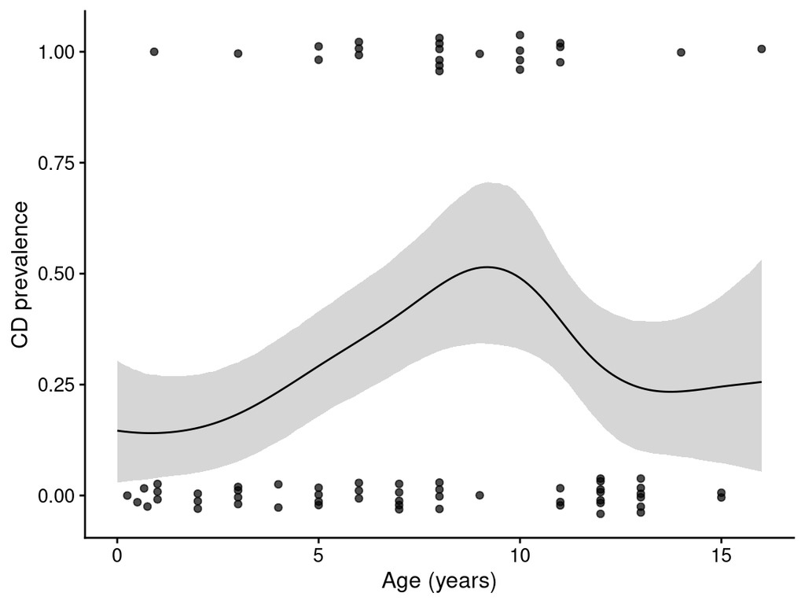

```r
f <- tibble(Age = seq(0, 16, by = 0.1)) %>%
    bind_cols(., fitted(b.age, ., probs = c(0.1, 0.9)) %>% as_tibble)
f %>%
    ggplot(aes(Age, Estimate)) +
    geom_ribbon(aes(ymin = Q10, ymax = Q90),
        linetype = 0, alpha = 0.2) +
    geom_line() +
    geom_quasirandom(data = tb3, aes(Age, as.integer(CD) - 1),
        inherit.aes = FALSE, groupOnX = FALSE, width = 0.05, alpha = 0.7) +
    labs(y = "CD prevalence", x = "Age (years)")
```

We can see that the spline captures the higher prevalance at intermediate ages and the possible uptick at very old ages.

Now, add the age spline to the multivariate model:

```r
b3 <- brm(data = tb3, family = bernoulli,
    CD ~ Ab_status + GI_status + Sex + s(Age) + CH,
    prior = base_prior,
    control = list(adapt_delta = 0.98)
)
```

Check the posteriors and chains:

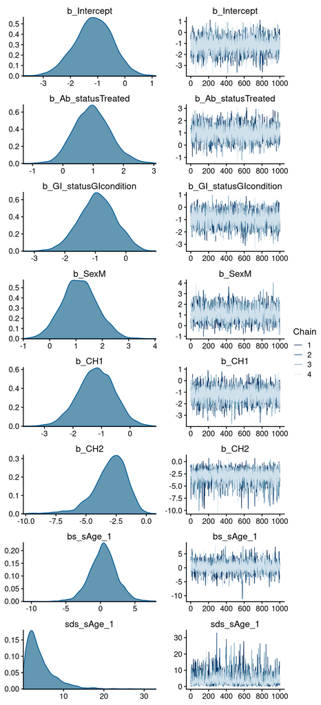

```r
plot(b3, N = 10)
```

Compare the CH coefficients of the three models:

```r
b1 %>% fixef(probs = c(0.05, 0.1, 0.9, 0.95), pars = c("CH1", "CH2"))
```

```
##      Estimate Est.Error        Q5       Q10        Q90        Q95
## CH1 -1.175785  0.474441 -1.958827 -1.792615 -0.5648845 -0.4109184
## CH2 -3.602115  1.334385 -6.087342 -5.322466 -2.1284314 -1.8028743
```

```r
b2 %>% fixef(probs = c(0.05, 0.1, 0.9, 0.95), pars = c("CH1", "CH2"))
```

```
##      Estimate Est.Error        Q5       Q10        Q90        Q95
## CH1 -1.105892 0.5108735 -1.969386 -1.750174 -0.4626891 -0.2858227
## CH2 -3.459085 1.3701222 -6.017034 -5.225482 -1.9254920 -1.5979412
```

```r
b3 %>% fixef(probs = c(0.05, 0.1, 0.9, 0.95), pars = c("CH1", "CH2"))
```

```
##      Estimate Est.Error        Q5       Q10        Q90        Q95
## CH1 -1.186955 0.6381064 -2.266190 -2.005401 -0.3805906 -0.1721504
## CH2 -3.000585 1.4249740 -5.501732 -4.833196 -1.4047209 -1.0431328
```

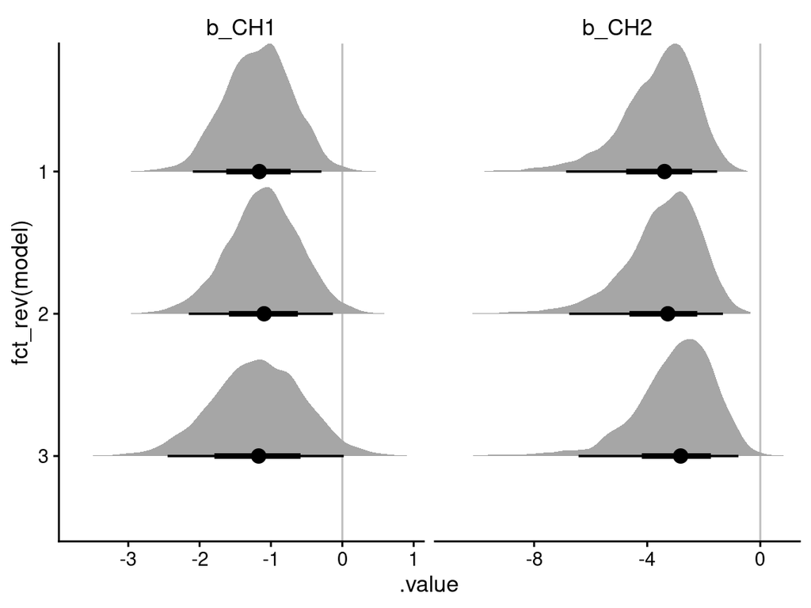

```r
list(b1, b2, b3) %>%
    map_dfr(gather_draws, `b_CH.`, regex = TRUE, .id = "model") %>%
    ggplot(aes(y = fct_rev(model), x = .value)) +
    geom_vline(xintercept = 0, color = "grey") +
    geom_halfeyeh(.width = c(0.66, 0.95)) +
    facet_wrap(~.variable, scales = "free_x")
```

The CH coefficients are consistent in the three models. The estimation error increases and the mean estimate of the CH2 effect lessens somewhat for the model with age, but greater shrinkage is expected from the smaller sample size.

Visualize the predictions of the full model in the absence of a GI condition,

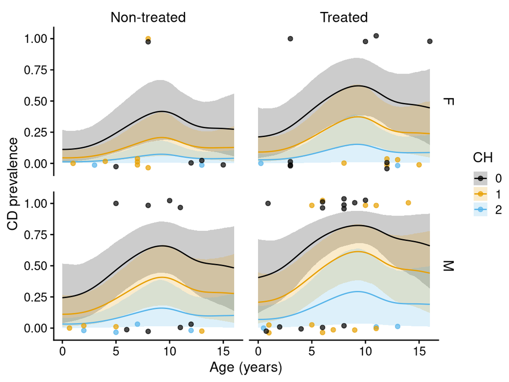

```r
f3 <- crossing(
    Age = seq(0, 16, by = 0.1),
    Ab_status = c("Non-treated", "Treated"),
    Sex = c("F", "M"),
    GI_status = c("Healthy"),
    CH = factor(c(0, 1, 2)),
    ) %>%
    bind_cols(., fitted(b3, ., probs = c(0.1, 0.9)) %>% as_tibble)
f3 %>%
    ggplot(aes(Age, Estimate, color = CH)) +
    geom_ribbon(aes(ymin = Q10, ymax = Q90, fill = CH),
        linetype = 0, alpha = 0.2) +
    geom_line() +
    facet_grid(Sex ~ Ab_status) +
    geom_quasirandom(data = tb3, aes(Age, as.integer(CD) - 1, color = CH),
        inherit.aes = FALSE, groupOnX = FALSE, width = 0.05, alpha = 0.7) +
    ggthemes::scale_color_colorblind() +
    ggthemes::scale_fill_colorblind() +
    labs(y = "CD prevalence", x = "Age (years)") +
    theme(panel.spacing.y = unit(5, "mm"))
```